# Coursework Report

*N* removed NAs: 2

*N* removed typo: 1

*N* removed <18: 17

*N* total clean: 130

| Group | *N* | *M*<sub>age</sub> | *M*<sub>rating</sub> |
| --- | --- | --- | --- |
| Control | 71 | 21.44 | 5.83 |
| Experim | 59 | 21.20 | 6.91 |

**Main analysis results**

*t*(128) = -7.5, *p* < .001

[interactive chart not shown]

[figure not shown]

[interactive chart not shown]

# Coursework Report

Analysing Data, Spring 2020

# Methods

## Participants

150 participants took part in the experiment (*M*<sub>age</sub> = 21.12, *SD*<sub>age</sub> = 1.76, range = 18 - 25). Although 150 participants participated within the experiment, 1 person was removed from the experiment due to the fact that there were gaps within their data. After this, 24 participants were removed due to an age filter as participants must be between the ages of 18 and 25. This finally left 125 participants in the experiment. Participant data for each condition is shown in Table 1.

Table 1 *Descriptive statistics by condition*

| Condition | *N* | % | *M*<sub>age</sub> | *SD*<sub>age</sub> |
| --- | --- | --- | --- | --- |
| white | 69 | 55.2 | 21.26 | 1.62 |
| red | 56 | 44.8 | 20.95 | 1.91 |

## Design

The research aimed to investigate whether the colour red influences a woman’s attraction to men and the hypothesis that the colour red will enhance a woman’s attraction to men through societal perceptions linked to the colour red such as their status based on Elliot et al.’s (2010) original experiment.

Participants were randomly allocated to look at a photo of a man in black and white either on a red or white background. The main variable measured was perceived attractiveness on a rating scale of 1-9. This was measured through 3 questions - “How attractive do you think this person is?”, “How attractive is this person to look at?” and “If I were to meet the person in this picture face to face, I would think he is attractive” (Elliot et al. 2010). Participants answered by rating the man on a scale of 1-9 so a high score of 9 can be interpreted as being “extremely attractive”. Additionally, a composite attractiveness score was created through averaging all attractiveness ratings, so this result was still on a scale of 1-9.

Overall, the attractiveness ratings obtained from 56 women in the red condition will be higher than the ratings obtained from the 69 women in the white condition. This will be measured through a comparison of the means between the two conditions after creating a composite score of attractiveness and by carrying out a t-test on the results.

# Results

A composite score was created by averaging the sum of the 3 attractiveness scores measured by the questions mentioned above and this was created to compare the mean ratings the conditions. The pattern shown within the results was that the participants within the red group had a higher mean rating of attractiveness for the men with the red background over the white background. The comparison of the two conditions is shown below in Table 2 which shows that the mean difference between the two conditions is 1.1.

Table 2 *Mean attractiveness ratings*

| Condition | *M*<sub>attractiveness</sub> | *SD*<sub>attractiveness</sub> |
| --- | --- | --- |
| white | 5.85 | 0.88 |
| red | 6.95 | 0.73 |

An independent-measures t-test was carried out to compare the means between the two conditions. As predicted, those in the red condition gave higher mean ratings of attractiveness (*M* = 6.95), than those in the white condition (*M* = 5.85) which shows that the difference was found to be significant (*M*<sub>diff</sub> = 1.1). This difference was found at the 95% CI [-1.39, -0.81] which represents how at the 95% confidence level there is a significant difference as at *t* (123) = -7.5, then *p* = 0. As p < 0.05, we can reject the null hypothesis implying that colour does influence attraction as there is a significant difference between the means.

A linear model was used to identify if there was a relationship between attractiveness ratings and the colour condition. The null hypothesis of this model is that there will be no relationship between attraction and the colour condition. The linear model, (*b* = 1.1 , SE(*b*) = 0.15) shows that the change in the outcome associated with a unit change increases by 1.1. The linear model showed that at the 95% confidence intervals [0.81, 1.39], the values of *t* = 7.5, and *p* < 0.001 demonstrates a significant positive relationship between the colour condition and attractiveness rating. The linear model would be expected to generalise well to the general population as the values for R<sup>2</sup> are similar (R<sup>2</sup><sub>adj</sub> = 0.31). Although R<sup>2</sup> (0.31) demonstrates the variance that can be accounted for in the model, this model may not be the best fit for the data as it is a low value.

The graph below demonstrates these results showing that those in the red condition rated the men to be more attractive proving the hypothesis.

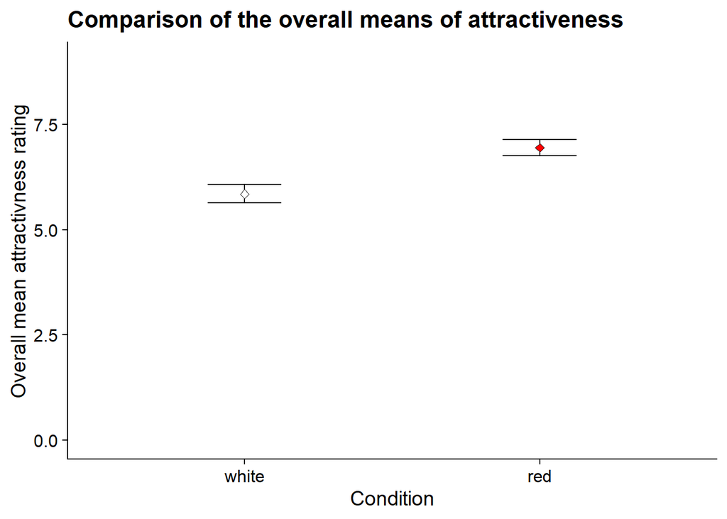

# Discussion

This study aimed to investigate whether women find men more attractive in conjunction with the colour red. Primarily, a composite score of attractiveness was created and after comparing the means from both conditions, participants in the red group rated the men higher in perceived attractiveness. An independent *t* test was conducted investigating whether the results collected were significant. The results were proven to be significant showing that colour influences attractiveness ratings of men by women. A linear regression model was used which identified that there was a positive relationship between colour condition and attraction ratings therefore leading to the acceptance of the alternative hypothesis. The data collected and the models used allowed successful hypothesis testing as the data supports the hypothesis of the study. The linear model suggested the model would general well to the population due to the similarity in R<sup>2</sup> and adjusted R<sup>2</sup>.

There are clear implications from the research carried out as Francis (2010) found that Elliot et al.’s (2010) research could not confirm the claims surrounding the relationship between the colour red and attraction. The original study was subject to publication bias as it differs from other studies on this topic such as research by Sullivan, Kazlauciunas and Guthrie (2020) who found no relationship between men choosing the colour red for women to wear suggesting the ‘red effect’ does not exist, so this study is providing false information to the public. This provides psychologists with poor scientific credit and it could also lead to a loss of trust within the public as false evidence is provided to them surrounding. This can again be proven through research by Lehmann and Calin-Jageman (2017) who found that there was no relationship between the colour red and perceived attractiveness. They identified that potentially this difference could be because the individuals in the photograph are less attractive. Elliot et al. (2013) suggested a larger sample may identify a significant effect however, there are a large amount of studies disproving the ‘red effect’ such as Guéguen (2012) who investigated whether red lipstick influences attraction however, research showed that it was not the colour of the lipstick but that the woman was wearing lipstick proving again that the results from this study are inaccurate.

The results from this study and from Elliot et al.’s (2010) original experiment demonstrated that participants in the red condition rated the men to be more attractive. Both studies support the original hypothesis that colour influences attraction ratings suggesting that the ‘red effect’ is a real effect. Several replications and similar studies have been carried out investigating the effect of the colour red on attractiveness. Berthold, Reese and Martin (2017) investigated whether the colour red influenced an individual’s perception of their own attractiveness. They carried out several studies involving participants rating their own self-attractiveness in red and their self-perceived status and sexual receptivity. They found the colour red caused participants to rate themselves as more attractive, to be of a higher status and they also reported higher sexual receptiveness however they found that there were no differences between genders.

In contrast to previous studies, Peperkoorn, Robert and Pollet (2016) investigated the ‘red effect on attractiveness’ but found that there was no relationship between the colour red and perceptions of attractiveness. This contradicts the results from this study and the original study this was based on. It provides doubt about the ‘red effect’, so although there may have been a correlation between attractiveness and the colour red in some studies, this correlation may have been caused by an unknown variable. Another study carried out by Hesslinger and Carbon (2015) replicated the experiments carried out within Elliot et al.’s (2010) original research but they improved the original experiment to remove the limitations. From their replication of Elliot et al.’s 2010 study, they found contradicting results as there was no statistically significant effect on perceived attractiveness due to the colour red suggesting there may be limitations in the original research. This therefore suggests that the ‘red effect’ may not be a real effect which provides contradicting results.

Within this study, there are several limitations leading to limited findings. Primarily, this study only researched the ‘red effect’ on women as it only looked at women’s perceptions of attractiveness whereas this effect may be different for men so these results may not be generalisable to the population. Peperkoorn et al. (2016) carried out a similar study to Elliot et al. (2010) however, they used males and discovered that there was no relationship between perceptions of attractiveness and the colour red. This implies that gender may influence the impact of the ‘red effect’. Additionally, a meta-analysis of the ‘red effect’ was carried out by Lehmann et al. (2018) who discovered that there was a statistical difference with the colour red influencing men’s perception of attraction however, these results were inconsistent, so implies the red effect is non-existent. A further limitation is from the linear regression model analysis as although the values for R<sup>2</sup> and adjusted R<sup>2</sup> are similar, their values are very small. Only 30% of the variance within the model can be accounted for which is a limitation of the model as although the findings are significant, it suggests that the model is not suited to the data. This limits the findings collected as other models may better explain the relationship between attraction and the colour red. Additionally, attractiveness was measured through a rating scale however this may not be an accurate method as it could be linked to bias.

Further research on this topic could identify if environmental elements can influence perceptions of attraction. These studies could include research investigating both heterosexual and homosexual individuals to identify whether sexuality influences the ‘red effect’. Furthermore, the data collected within this experiment is calculated from a rating scale measuring perceived attractiveness however, this may not be the best method to use so in future studies, they could avoid using a rating scale as it is a self-report method so it may not be as scientific. A study of attraction carried out by Cooper et al. (2012) showed that when looking at an attractive individual, the ventromedial prefrontal cortex or the rostromedial prefrontal cortex is activated indicating that this individual is perceived to be attractive. This could be used within future studies using a repeated measures design and identifying if there was a difference in brain activity in these areas based on the condition. An issue with studying attraction however is that, as found by Young (2015), that these individuals may be rated attractive before adding the colour red so therefore attractiveness may falsely be linked to the colour red. If this study were to be researched further, they could also include a larger age bracket to identify if this perceived ‘red effect’, is applicable to all ages.

# References

Berthold, A., Reese, G., Martin, J. (2017). The Effect of Red Color on Perceived Self-attractiveness: Red Color and Self-Attractiveness. *European Journal of Social Psychology, 47*(5), 645-652. Doi: 10.1002/ejsp.2238

Furey, T., O’Doherty, J. (2012). Dorsomedial Prefrontal Cortex Mediates Rapid Evaluations Predicting the Outcome of Romantic Interactions. *Journal of Neuroscience, 32*(45), 15647-15656. Doi:10.1523/JNEUROSCI.2558-12

Elliot, A., Maier, M. (2013). The Red-Attractiveness Effect, Applying the Ioannidis and Trikalinos (2007b) Test, and the Broader Scientific Context: A Reply to Francis (2013). *Journal of Experimental Psychology: General, 142*(1), 297-300. Doi:10.1037/a0029592

Elliot, A., Niesta, D.K., Greitemeyer, T., Lichenfeld, S., Gramzow, R.H., Maier, M.A., Liu, Huijun. (2010). Red, Rank, and Romance in Women Viewing Men. *Journal of Experimental Psychology, 139*(3), 399-417. Doi: 10.1037/a0019689

Francis, G. (2013) Publication Bias in “Red, Rank and Romance in Women Viewing Men”, by Elliot et al. (2010). *Journal of Experimental Psychology: General, 142*(1), 292-296. Doi: 10.1037/a0027923

Guéguen, N. (2012). Does Red Lipstick Really Attract Men? An Evaluation in a Bar. *International Journal of Psychological Studies, 4*(2), 206-209. Doi: 10.5539/ijps.v4n2p206

Hesslinger, V., Goldbach, L., Carbon, C. (2015). Men in Red: A Re-examination of the Red-Attractiveness Effect. *Psychonomic Bulletin & Review, 22*(4), 1142-1148. Doi:10.3758/s13423-015-0866-8

Lehmann, G., Elliot, A., Calin-Jageman, R. (2018). Meta-Analysis of the Effect of Red on Perceived Attractiveness. *Evolutionary Psychology, 16*(4). Doi:10.1177/1474704918802412

Lehmann, G., Calin-Jageman, R. (2017). Is Red Really Romantic?. *Social Psychology, 48*(3), 174-183. Doi:10.1027/1864-9335/a000296

Peperkoorn, L., Roberts, S., Pollet, T. (2016). Revisiting the Red Effect on Attractiveness and Sexual Receptivity: No Effect of the Color Red on Human Mate Preferences. *Evolutionary Psychology, 14*(4). Doi: 10.1177/1474704916673841

Sullivan, C., Kazalauciunas, A., Guthrie, J. (2020). Colored Apparel and its Potential Influence on Heterosexual Attraction. *Color Research and Application, 45*(2), 362-373. Doi: 10.1002/col.22458

Young,S. (2015). The Effect of Red on Male Perceptions of Female Attractiveness: Moderation by Baseline Attractiveness of Female Faces. *European Journal of Social Psychology, 45*(2), 146-151. Doi:10.1002/ejsp.2098